# Final Project

Please implement the Final project . Use four algorithms: Neural Network, Ensemble technique (Random Forest or Gradient Descent or Super Learners ) , Regression and SVM Support Vector Machine.  
Project specification is uploaded under Modules. Please implement 4 distinct questions per person.  
Please upload the .ipynb file, .html file/pdf file and data file  
STEP 1: Formulate the project research framework.  
Data source: https://www.kaggle.com/harasissingh/admission-predict  
Research Questions:  
1. predict if research is needed in a university given university rating, gre score and toefl score of students applying to that university.  
2. Compare the accuracy of each of the 4 algorithms.

```python
import numpy as np
import pandas as pd
from sklearn.model_selection import train_test_split
from sklearn.naive_bayes import GaussianNB
from sklearn.metrics import accuracy_score
import matplotlib.pyplot as plt
import seaborn as sns
from sklearn.datasets import load_iris
from sklearn.model_selection import train_test_split
from sklearn.naive_bayes import GaussianNB
from sklearn.model_selection import KFold
from sklearn.model_selection import cross_validate
from sklearn.metrics import classification_report, confusion_matrix
from sklearn import preprocessing
from sklearn import utils
from pandas.plotting import scatter_matrix
```

```python
df = pd.read_csv('Admission_Predict.csv')
del df['Serial No.']
print(df.head(5))
#normalizing and standardizing data
print(df.isnull().values.any())
```

```
   GRE Score  TOEFL Score  University Rating  SOP  LOR   CGPA  Research  \
0        337          118                  4  4.5   4.5  9.65         1
1        324          107                  4  4.0   4.5  8.87         1
2        316          104                  3  3.0   3.5  8.00         1
3        322          110                  3  3.5   2.5  8.67         1
4        314          103                  2  2.0   3.0  8.21         0

   Chance of Admit
0              0.92
1              0.76
2              0.72
3              0.80
4              0.65
False
```

STEP 2: Data Science Analysis  
2.1 Descriptive Statistics  
a)For the categorical variable create a frequency distribution.  
categorical variable: University Rating (1-5)  
quantative variable: research ( 0 or 1)  
b)For the categorical variable create a bar diagram.  
c)For thequantitative variable create numerical summaries grouped by a categorical variable.  
d)For quantitative variable create a histogram and a boxplotgrouped by categorical

```
3    133
2    107
4     74
5     60
1     26
Name: University Rating, dtype: int64 describe
```

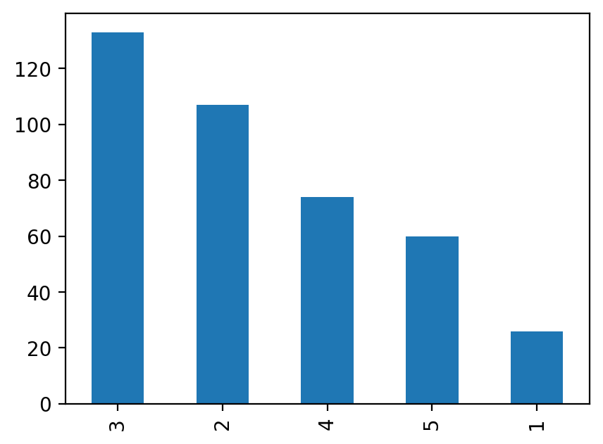

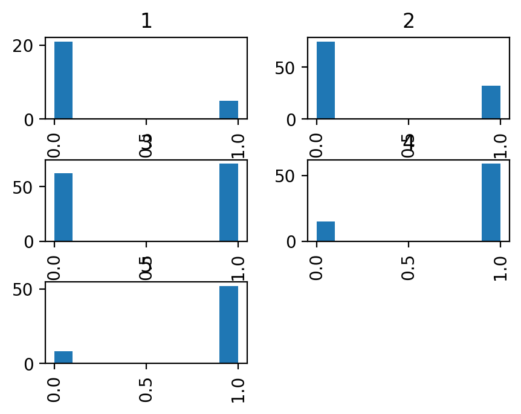

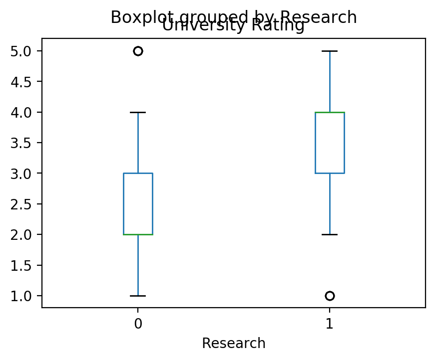

```python
#print frequence distribution for the categorical
print(df['University Rating'].value_counts(), 'describe')

#bar diagram for categorical variable
uni= df['University Rating']

uni.value_counts().plot(kind='bar')
df['Research'].hist(by=df['University Rating'])
df.boxplot(by='Research', column='University Rating', grid=False)
plt.show()
```

2.2 Correlation and Regression:  
Amongst the quantitative variables generate Relationships and Associations.  
Identify two quantitative variables of interest that might be correlated and then perform the following analysis: GRE Score and TOEFL Score.  
a) Find the correlation coefficient between the explanatory and response variable.  
b) Create a scatter diagram and find R squared.  
c) Validate if the correlation is significant by conducting a Hypothesis test.  
Provide your rationale and justify your findings regarding the correlation between two quantitative variables of interest.  
If a person scores high on the TOEFL then he is most likely going to have a higher score on his GRE test as well.